# ML Project

Parth

21/10/2021

## Background

Using devices such as Jawbone Up, Nike FuelBand, and Fitbit it is now possible to collect a large amount of data about personal activity relatively inexpensively. These type of devices are part of the quantified self movement - a group of enthusiasts who take measurements about themselves regularly to improve their health, to find patterns in their behavior, or because they are tech geeks. One thing that people regularly do is quantify how much of a particular activity they do, but they rarely quantify how well they do it. In this project, our goal will be to use data from accelerometers on the belt, forearm, arm, and dumbell of 6 participants. They were asked to perform barbell lifts correctly and incorrectly in 5 different ways. More information is available from the website here: http://groupware.les.inf.puc-rio.br/har (see the section on the Weight Lifting Exercise Dataset).

## Intended Results

The goal of this project is to predict the manner in which they did the exercise. This is the “classe” variable in the training set. You may use any of the other variables to predict with. You should create a report describing how you built your model, how you used cross validation, what you think the expected out of sample error is, and why you made the choices you did. You will also use your prediction model to predict 20 different test cases.  
1. Your submission should consist of a link to a Github repo with your R markdown and compiled HTML file describing your analysis. Please constrain the text of the writeup to < 2000 words and the number of figures to be less than 5. It will make it easier for the graders if you submit a repo with a gh-pages branch so the HTML page can be viewed online (and you always want to make it easy on graders :-).  
2. You should also apply your machine learning algorithm to the 20 test cases available in the test data above. Please submit your predictions in appropriate format to the programming assignment for automated grading. See the programming assignment for additional details.

## Reproducibility

In order to reproduce the same results, you need a certain set of packages as well as setting a pseudo random seed equal to the one I have used.  
`Note`: To install, for instance, the `rattle` package in R, run this command: `install.packages("rattle")`.  
The following Libraries were used for this project, which you should install and load them in your working environment.

```r
 # Setting working directory first
setwd("~/Machine Learning")

 # Removes all objects from the current workspace (R memory)
rm(list=ls())

 # Libraries
library(knitr)
library(dplyr)
```

```r
library(rpart)
library(rpart.plot)
library(rattle)
library(randomForest)
library(corrplot)
library(caret)
library(RColorBrewer)
library(gbm)
 # Set seed to create reproducibility
set.seed(12345)
```

## Loading the Data.

```r
TrainData <- read.csv(url("https://d396qusza40orc.cloudfront.net/predmachlearn/pml-training.csv"),header=TRUE)
dim(TrainData)
```

```
## [1] 19622   160
```

```r
ValidData <- read.csv(url("https://d396qusza40orc.cloudfront.net/predmachlearn/pml-testing.csv"),header=TRUE)
dim(ValidData)
```

```
## [1]  20 160
```

## Data Cleaning

In order to get a clean data, we will remove those columns that have at least 90% of this kind of observations. We can also get rid of the first variables, as they contain ID and timestamp information that are not necessary to build the model.

```r
 # Removing NA's, empty values, and unnecesary variables in the Trainning dataset.
EmptyCols <- which(colSums(is.na(TrainData) |TrainData=="")>0.9*dim(TrainData)[1])
TrainDataClean <- TrainData[,-EmptyCols]
TrainDataClean <- TrainDataClean[,-c(1:7)]
dim(TrainDataClean)
```

```
## [1] 19622    53
```

```r
 # Removing NA's, empty values in the Test dataset.
EmptyCols <- which(colSums(is.na(ValidData) |ValidData=="")>0.9*dim(ValidData)[1])
ValidDataClean <- ValidData[,-EmptyCols]
ValidDataClean <- ValidDataClean[,-1]
dim(ValidDataClean)
```

```
## [1] 20 59
```

## Data Partitioning for prediction

Here, we prepare the data for prediction by splitting the training data into 70% as train data and 30% as test data. This splitting will serve to test the model accuracy.

```r
set.seed(12345)
inTrain <- createDataPartition(TrainDataClean$classe, p = 0.7, list = FALSE)
TrainData <- TrainDataClean[inTrain, ]
TestData <- TrainDataClean[-inTrain, ]
dim(TrainData)
```

```
## [1] 13737    53
```

## Exploratory Data Analysis

We can take a look into our data and explore the correlations between all the variables before modeling.

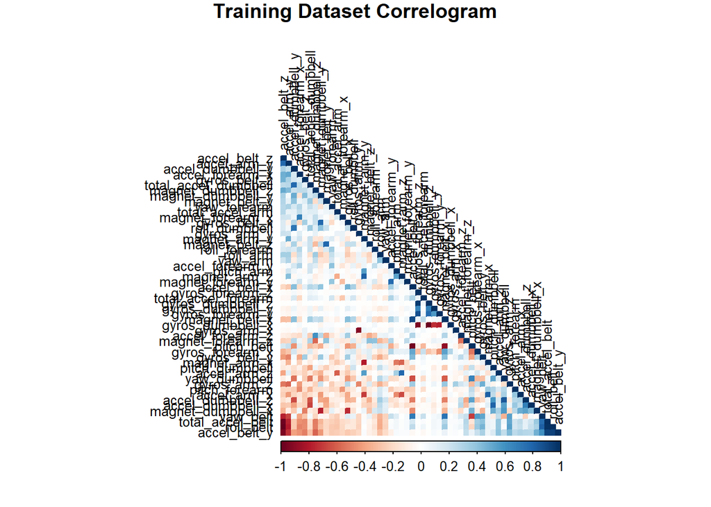

```r
corMatrix <- cor(TrainData[, -53])
corrplot(corMatrix, order = "FPC", method = "color", type = "lower",
         tl.cex = 0.8, tl.col = rgb(0, 0, 0),mar = c(1, 1, 1, 1), title = "Training Dataset Correlogram")
```

```r
# Count the number of variables that are highly correlated with another one
M <- abs(cor(TrainData[,-53])); diag(M) <- 0
M <- which(M > 0.8, arr.ind = T)
M <- dim(M)[1]
M
```

```
## [1] 38
```

## Cross-Validation

In order to limit the effects of overfitting, and improve the efficicency of the models, we will use the cross-validation technique. Cross-validation is done for each model with K = 3. This is set in the above code chunk using the fitControl object as defined below:

```r
fitControl <- trainControl(method='cv', number = 3)
```

## Decision Trees Model

[figure not shown]

```r
# Decision Trees Model
TrainData$classe=factor(TrainData$classe)
DT_Model <- train(classe~., data=TrainData, method="rpart", trControl=fitControl)
#  Plot
fancyRpartPlot(DT_Model$finalModel)
```

```r
# Testing the model
DT_Predict <- predict(DT_Model,newdata=TestData)
DT_cm <- confusionMatrix(table(TestData$classe,DT_Predict))

# Display confusion matrix and model accuracy
DT_cm
```

```
## Confusion Matrix and Statistics
##
##    DT_Predict
##        A    B    C    D    E
##   A 1525   29  116    0    4
##   B  484  385  270    0    0
##   C  499   37  490    0    0
##   D  423  187  354    0    0
##   E  153  159  289    0  481
##
## Overall Statistics
##
##                Accuracy : 0.4895
##                  95% CI : (0.4767, 0.5024)
##     No Information Rate : 0.524
##     P-Value [Acc > NIR] : 1
##
##                   Kappa : 0.3324
##
##  Mcnemar's Test P-Value : NA
##
## Statistics by Class:
##
##                      Class: A Class: B Class: C Class: D Class: E
## Sensitivity            0.4945  0.48306  0.32258       NA  0.99175
## Specificity            0.9468  0.85181  0.87723   0.8362  0.88870
## Pos Pred Value         0.9110  0.33802  0.47758       NA  0.44455
## Neg Pred Value         0.6298  0.91319  0.78823       NA  0.99917
## Prevalence             0.5240  0.13543  0.25811   0.0000  0.08241
## Detection Rate         0.2591  0.06542  0.08326   0.0000  0.08173
## Detection Prevalence   0.2845  0.19354  0.17434   0.1638  0.18386
## Balanced Accuracy      0.7206  0.66743  0.59991       NA  0.94023
```

```r
# Model Accuracy
DT_cm$overall[1]
```

```
##  Accuracy
## 0.4895497
```

## Random Forests Model

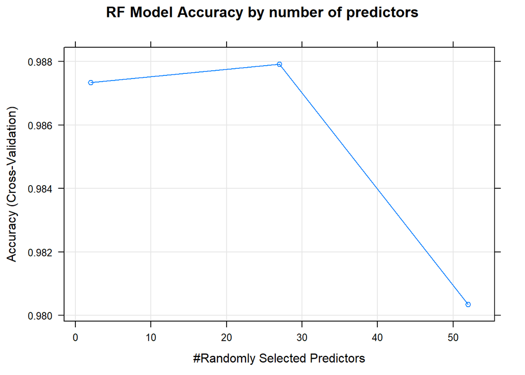

```r
# Random Forests Model
TrainData$classe=factor(TrainData$classe)
RF_Model <- train(classe~., data=TrainData, method="rf", trControl=fitControl, verbose=FALSE)
# Plot
plot(RF_Model,main="RF Model Accuracy by number of predictors")
```

```r
# Testing the model
RF_Predict <- predict(RF_Model,newdata=TestData)
RF_cm <- confusionMatrix(table(TestData$classe,RF_Predict))

# Display confusion matrix and model accuracy
RF_cm
```

```
## Confusion Matrix and Statistics
##
##    RF_Predict
##        A    B    C    D    E
##   A 1673    1    0    0    0
##   B    6 1130    3    0    0
##   C    0    5 1018    3    0
##   D    0    0    8  955    1
##   E    0    0    2    1 1079
##
## Overall Statistics
##
##                Accuracy : 0.9949
##                  95% CI : (0.9927, 0.9966)
##     No Information Rate : 0.2853
##     P-Value [Acc > NIR] : < 2.2e-16
##
##                   Kappa : 0.9936
##
##  Mcnemar's Test P-Value : NA
##
## Statistics by Class:
##
##                      Class: A Class: B Class: C Class: D Class: E
## Sensitivity            0.9964   0.9947   0.9874   0.9958   0.9991
## Specificity            0.9998   0.9981   0.9984   0.9982   0.9994
## Pos Pred Value         0.9994   0.9921   0.9922   0.9907   0.9972
## Neg Pred Value         0.9986   0.9987   0.9973   0.9992   0.9998
## Prevalence             0.2853   0.1930   0.1752   0.1630   0.1835
## Detection Rate         0.2843   0.1920   0.1730   0.1623   0.1833
## Detection Prevalence   0.2845   0.1935   0.1743   0.1638   0.1839
## Balanced Accuracy      0.9981   0.9964   0.9929   0.9970   0.9992
```

```r
# Model Accuracy
RF_cm$overall[1]
```

```
##  Accuracy
## 0.9949023
```

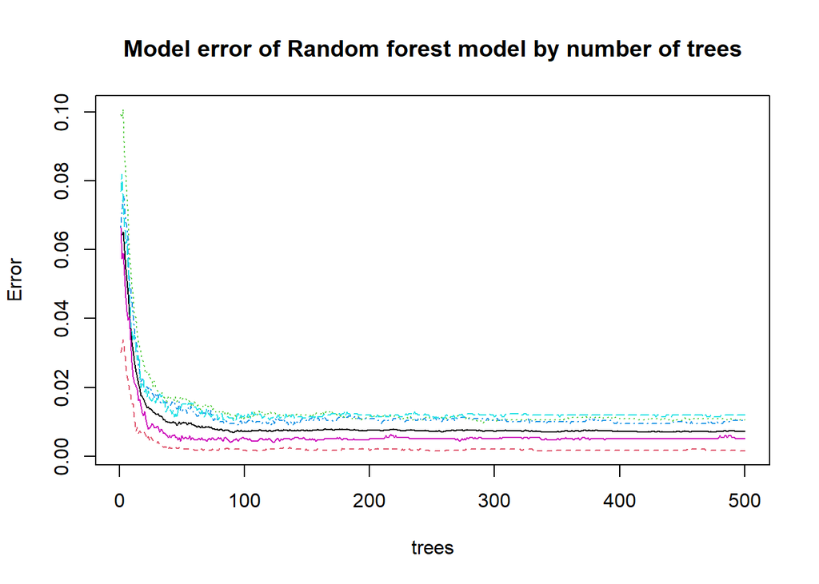

```r
plot(RF_Model$finalModel,main="Model error of Random forest model by number of trees")
```

## Generalized Boosted model

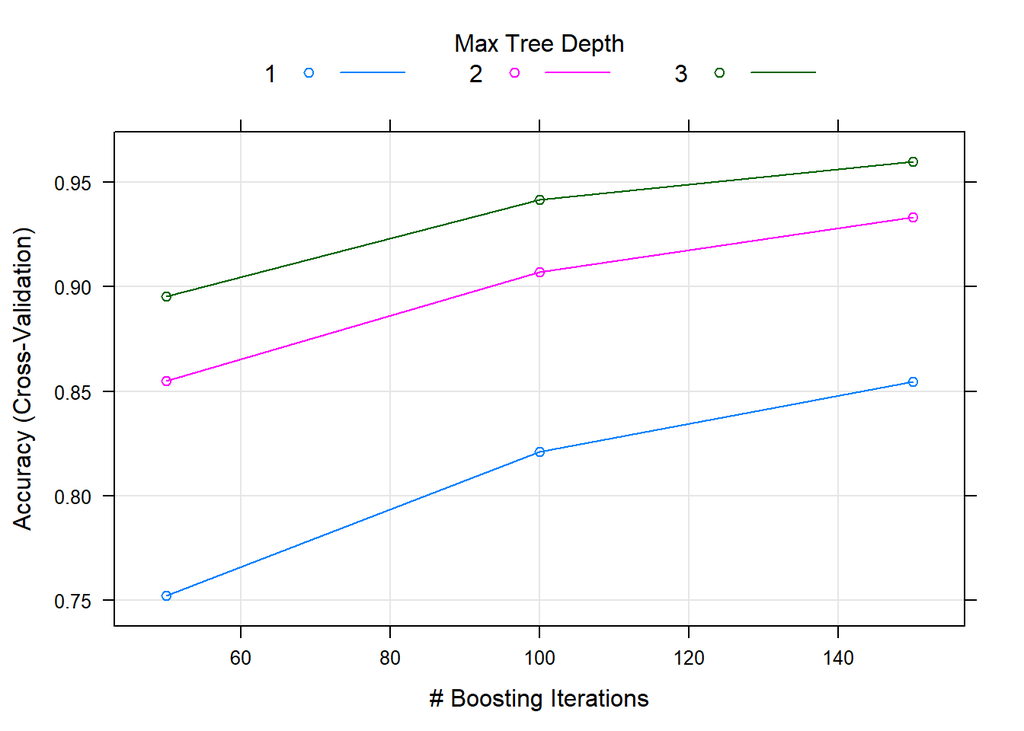

```r
# Generalized Boosted Model
TrainData$classe=factor(TrainData$classe)
GBM_Model <- train(classe~., data=TrainData, method="gbm", trControl=fitControl, verbose=FALSE)
#  Plot
plot(GBM_Model)
```

```r
# Testing the model
GBM_Predict <- predict(GBM_Model,newdata=TestData)
GBM_cm <- confusionMatrix(table(TestData$classe,GBM_Predict))

# Display confusion matrix and model accuracy
GBM_cm
```

```
## Confusion Matrix and Statistics
##
##    GBM_Predict
##        A    B    C    D    E
##   A 1647   19    2    5    1
##   B   41 1059   35    2    2
##   C    0   40  971   14    1
##   D    1    2   36  918    7
##   E    0   12   12    9 1049
##
## Overall Statistics
##
##                Accuracy : 0.959
##                  95% CI : (0.9537, 0.964)
##     No Information Rate : 0.287
##     P-Value [Acc > NIR] : < 2.2e-16
##
##                   Kappa : 0.9482
##
##  Mcnemar's Test P-Value : 1.413e-05
##
## Statistics by Class:
##
##                      Class: A Class: B Class: C Class: D Class: E
## Sensitivity            0.9751   0.9355   0.9195   0.9684   0.9896
## Specificity            0.9936   0.9832   0.9886   0.9907   0.9932
## Pos Pred Value         0.9839   0.9298   0.9464   0.9523   0.9695
## Neg Pred Value         0.9900   0.9846   0.9825   0.9939   0.9977
## Prevalence             0.2870   0.1924   0.1794   0.1611   0.1801
## Detection Rate         0.2799   0.1799   0.1650   0.1560   0.1782
## Detection Prevalence   0.2845   0.1935   0.1743   0.1638   0.1839
## Balanced Accuracy      0.9843   0.9593   0.9541   0.9795   0.9914
```

```r
# Model Acuracy
GBM_cm$overall[1]
```

```
##  Accuracy
## 0.9590484
```

## Applying the best model to the validation data

```r
# Model Validation
Prediction_Test <- predict(RF_Model,newdata=ValidDataClean)
Prediction_Test
```

```
##  [1] B A B A A E D B A A B C B A E E A B B B
## Levels: A B C D E
```